# Reproducible Research: Peer Assessment 1

rudini1

15.12.2017

## Loading and preprocessing the data

The file can be downloaded at the specified site. Alternatively the file is also located on the GitHub repository cloned.

```r
if(!file.exists("activity.csv")){
download.file("https://d396qusza40orc.cloudfront.net/repdata%2Fdata%2Factivity.zip", "activitymonitoringdatafile.zip")
unzip("activitymonitoringdatafile.zip")
}
library(data.table)
library(lubridate)
library(dplyr)
library(ggplot2)

# Sys.setlocale("LC_ALL","En") # this is necessary for the weekdays to be in english on a non-english system
# Sys.setenv(LANG = "en")

activity <- fread("activity.csv", header = TRUE, sep = ",", na.strings = "NA") %>%
mutate(date = as.POSIXct(date, "%Y-%m-%d"))
```

## What is mean total number of steps taken per day?

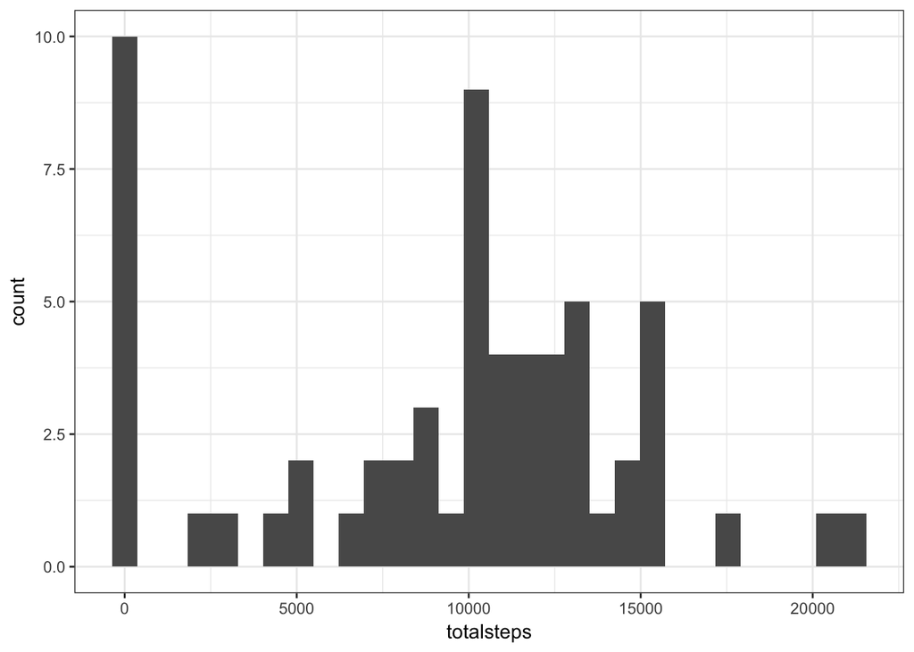

```r
totalstepsperday <- activity %>%
      group_by(date) %>%
      summarise(totalsteps = sum(steps, na.rm = TRUE))

# ggplot(data = totalstepsperday, aes(x =  date, y= totalsteps)) + geom_col()
ggplot(data = totalstepsperday, aes(x = totalsteps)) +
      geom_histogram(na.rm = TRUE) +
      theme_bw()
```

```r
meanstepsperday <- round(mean(totalstepsperday$totalsteps), 0)
medianstepsperday <- median(totalstepsperday$totalsteps)
```

- The median of the steps per day is : 10395
- The mean of the steps per day is : 9354

## What is the average daily activity pattern?

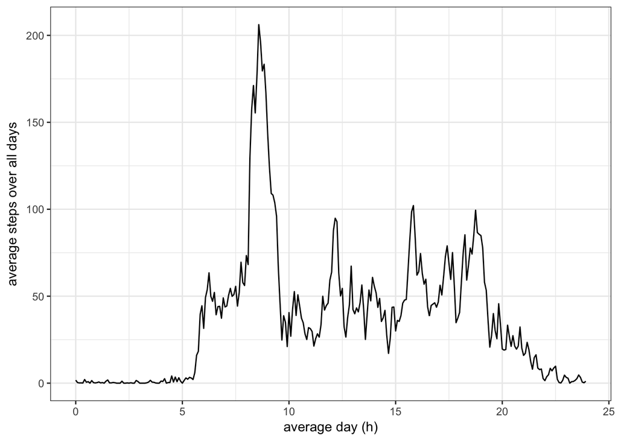

```r
averagestepsperinterval <- activity %>%
      group_by(interval) %>%
      summarise(meanstepsperinterval = mean(steps, na.rm = TRUE))

ggplot(data = averagestepsperinterval, aes(x = seq(from = 0, by = 5/60, along.with = interval), y = meanstepsperinterval)) +
      geom_line() +
      # geom_smooth(method = "loess", span = 0.05, se = FALSE) +
      theme_bw() +
      labs(x = "average day (h)", y = "average steps over all days")
```

```r
      maxsteps <- averagestepsperinterval[which.max(averagestepsperinterval$meanstepsperinterval),]$interval
```

The interval with maximum average steps is : 835 what is 8:35 in the morning

## Imputing missing values

first find the number of rows with missing (NA) values. This is equal to the number of rows that are not complete

```r
missingValues <- sum(!complete.cases(activity))
```

there are 2304 rows with missing values (from a total of 17568)

imputing missing values: strategy is to use the average steps of the intervals computed in the previous steps so for missing days, the average corresponding to the time interval is imputed

```r
activity %>%
  select_if(function(x) any(is.na(x))) %>%  # select the columns with NA
  summarise_each(funs(sum(is.na(.))))  # sum the NA's on the selected columns
```

```
##   steps
## 1  2304
```

only the variable “steps” contains missing values the next code block imputes the missing values in variable “steps”

```r
nas <- which(is.na(activity$steps))
corrs <- match(activity$interval, averagestepsperinterval$interval) # same as rep(1:288, times = 61)
activityImputed <- activity # first copy all data
activityImputed[nas,1] <- averagestepsperinterval[corrs[nas],2] # automatic coercion of steps form int to num
```

next code makes a histogram of the total steps per day as in the beginningm, but with the imputed dataset

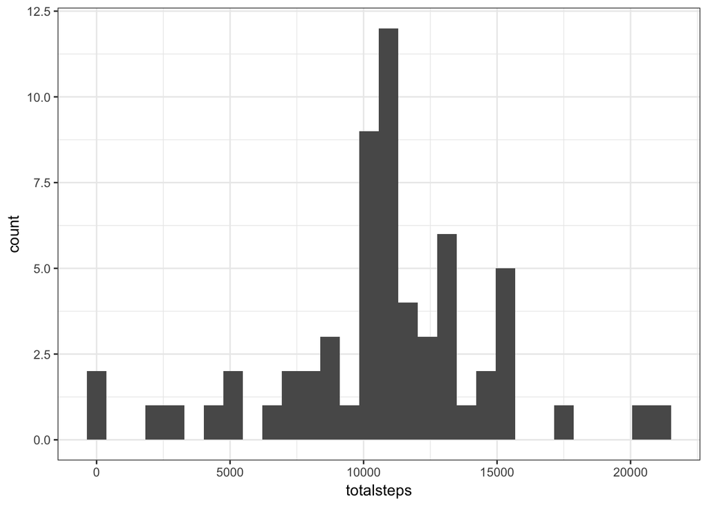

```r
totalstepsperdayimputed <- activityImputed %>%
      group_by(date) %>%
      summarise(totalsteps = sum(steps, na.rm = TRUE))

# ggplot(data = totalstepsperdayimputed, aes(x =  date, y= totalsteps)) + geom_col()
ggplot(data = totalstepsperdayimputed, aes(x = totalsteps)) +
      geom_histogram(na.rm = TRUE) +
      theme_bw()
```

```r
meanstepsperdayimp <- round(mean(totalstepsperdayimputed$totalsteps), 0)
medianstepsperdayimp <- median(totalstepsperdayimputed$totalsteps)
```

There were days full of NA’s giving a large number of days with zero steps. so the histogram differes in the nummer of days with zero steps when using imputed set.

- The median of the steps per day is : 10766
- The mean of the steps per day is : 10766

The distribution is now much more symmetric with both, median and mean beeing the same and different from the non-imputed data

## Are there differences in activity patterns between weekdays and weekends?

```r
# Definitions
weekend <- c("Samstag","Sonntag")  # I had to use the german words for saturday and Sunday here you have to use the words in your locale. I didn't find how to change it to english locale on my system

# weekday v. weekend
activityImputed <- activityImputed %>%
      mutate(isweekend = if_else(weekdays(date) %in% weekend, "weekend", "weekday")) %>%
      mutate(isweekend = as.factor(isweekend))
# table(activityImputed$isweekend)


stepsWeek <- activityImputed[activityImputed$isweekend == "weekday",]
stepsWeekend <- activityImputed[activityImputed$isweekend == "weekend",]

totalstepsperworkday <- stepsWeek %>% group_by(interval) %>%
      summarise(avgsteps=mean(steps, na.rm = TRUE))

totalstepsperweekendday <- stepsWeekend %>% group_by(interval) %>%
      summarise(avgsteps=mean(steps, na.rm = TRUE))
```

Plot the data

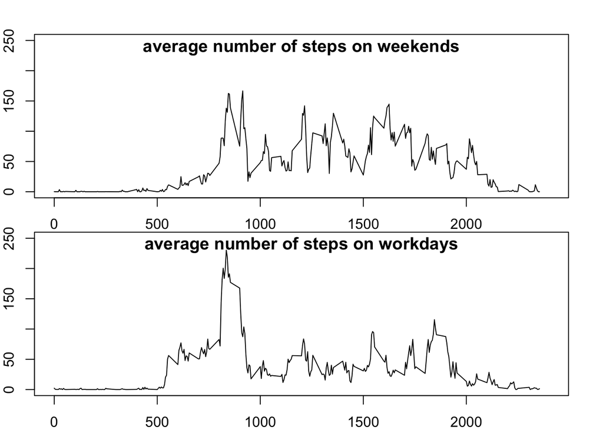

```r
par(mfrow=c(2,1),
    mar = c(1,1,1,1),
    oma = c(1,1,1,1))
with(totalstepsperweekendday,
     plot(interval, avgsteps, type = "l", xlim = c(0,2400), ylim = c(0,250)))
title("average number of steps on weekends", line = -1)
with(totalstepsperworkday,
     plot(interval, avgsteps, type = "l", xlim = c(0,2400), ylim = c(0,250)))
title("average number of steps on workdays", line = -1)
```

we see, that on workdays, the activity peaks higher around 8:30 than on weekends. However, on weekends activity is generally higher around noon and in the afternoon